# LI_Xinyu_PS2

## Introduction

Your name: **Xinyu Li**  
Deadline: Wed, Apr 18, 5:30pm

This homework is pretty long. But don't get desperate just yet, it largely repeats related questions, you have to modify your code just a little bit. We haven't talked about gradient and gradient ascent in the class, but take a look at the lecture notes (canvas/ les/readings) and the example notebook (canvas/- les/assignments). This should give you good enough background.

Please submit  
a) your code (notebooks, rmd, whatever) and  
b) the lab in a nal output form (html or pdf). Unlike PS1, you are free to choose either R or python for solving this problem set.

While some of the intermediate output may be informative, please don't include too many lines of it in your solutions!

Note: it includes questions you may want to answer on paper instead of computer. You are welcome to do it but please include the result as an image into your final file.

```python
import numpy as np
import matplotlib.pyplot as plt
%matplotlib inline
```

## 1 Gradient Ascent

### 1.1 Implement The 1D GA Algorithm

As a warm-up exercise, your first task is to implement 1-dimensional version of GA. Let's look at 1D case with f(x) = −x2. Pick an x0 (but don't pick x0 = 0), and set the learning rate R = 0.1.

#### **1. Start slow and manual.**

(a) What is the correct location of the maximum of this function? **to find the maximum of this function we need to take the derivative of the function f'(x) = -2x and set it to 0. then we found the max point is (0,0) for this function.**

(b) What is the gradient vector of the function? What is it's dimension? **the gradient vector for this function is ∇f(x) = -2x and the dimension is 1.**

(c) Compute the gradient at x0, ∇f(x0). set x0 = 1  
the gradient at x0 ∇f(x0) = -2.

(d) Compute x1 = x0 + R · ∇f(x0).  
**x1 = 1 + 0.1*(-2) = 0.8**

(e) Did we move closer to the maximum?  
**yes from 1 to 0.8, we moved closer to the max.**

#### 2. Now repeat the previous exercise on computer.

Choose at least one stopping criterion and it's parameter ε, and the bail-out number of iterations, R. Implement the above as an algorithm that at each step prints out the x value, the function's value f(x) and gradient ∇f(x). At the end it should print the solution, and also how many iterations it took for the loop to converge (to nish).

```python
# define the gradient_AS_1D function
# x initial x
# R learning rate
# eps prameter ε

def Gradient_AS_1D(x, R, eps, bail_out_iteration):
    def f(x): #define fx
        return -x**2
    def grad(x): # define gradient x
        return -2*x

    print("x: ", x) #print initial x
    print("f(x): ", f(x)) #print initial fx
    print ("∇f(x): ", grad(x), "\n") #print initial gradx

    count = 0 # set initial iteration to 0
    while abs(grad(x)) > eps:
        x_new = x + R * grad(x) # calculating the new x using the x+ R * grad(x) function

        print("x_new: ", x_new) #print new x
        print("f(x_new): ", f(x_new)) #print new fx
        print ("∇f(x_new): ", grad(x_new)) #print new gradx
        print ("iteration: ", count+1, "\n") #print iteration number
        count +=1
        x = x_new

Gradient_AS_1D(1, 0.1, 1e-7, 500)
```

```
x:  1
f(x):  -1
∇f(x):  -2

x_new:  0.8
f(x_new):  -0.6400000000000001
∇f(x_new):  -1.6
iteration:  1

x_new:  0.64
f(x_new):  -0.4096
∇f(x_new):  -1.28
iteration:  2

x_new:  0.512
f(x_new):  -0.262144
∇f(x_new):  -1.024
iteration:  3

x_new:  0.4096
f(x_new):  -0.16777216
∇f(x_new):  -0.8192
iteration:  4

x_new:  0.32768
f(x_new):  -0.10737418240000002
∇f(x_new):  -0.65536
iteration:  5

x_new:  0.26214400000000004
f(x_new):  -0.06871947673600003
∇f(x_new):  -0.5242880000000001
iteration:  6

x_new:  0.20971520000000005
f(x_new):  -0.04398046511104002
∇f(x_new):  -0.4194304000000001
iteration:  7

x_new:  0.16777216000000003
```

[output cut: 328 more lines]

```

x_new:  6.739986666787664e-08
f(x_new):  -4.542742026847548e-15
∇f(x_new):  -1.3479973333575327e-07
iteration:  74

x_new:  5.391989333430131e-08
f(x_new):  -2.9073548971824307e-15
∇f(x_new):  -1.0783978666860262e-07
iteration:  75

x_new:  4.313591466744105e-08
f(x_new):  -1.8607071341967557e-15
∇f(x_new):  -8.62718293348821e-08
iteration:  76
```

#### 3. Experiment with di erent starting values, learning rates and stopping parameter values. Comment and explain your ndings.

```python
# variation 1: set initial value and R the same and change the stopping parameter value eps from 1e-7 to  5e-3
Gradient_AS_1D(1, 0.1, 5e-3, 500)
```

```
x:  1
f(x):  -1
∇f(x):  -2

x_new:  0.8
f(x_new):  -0.6400000000000001
∇f(x_new):  -1.6
iteration:  1

x_new:  0.64
f(x_new):  -0.4096
∇f(x_new):  -1.28
iteration:  2

x_new:  0.512
f(x_new):  -0.262144
∇f(x_new):  -1.024
iteration:  3

x_new:  0.4096
f(x_new):  -0.16777216
∇f(x_new):  -0.8192
iteration:  4

x_new:  0.32768
f(x_new):  -0.10737418240000002
∇f(x_new):  -0.65536
iteration:  5

x_new:  0.26214400000000004
f(x_new):  -0.06871947673600003
∇f(x_new):  -0.5242880000000001
iteration:  6

x_new:  0.20971520000000005
f(x_new):  -0.04398046511104002
∇f(x_new):  -0.4194304000000001
iteration:  7

x_new:  0.16777216000000003
```

[output cut: 83 more lines]

```

x_new:  0.0037778931862957168
f(x_new):  -1.4272476927059604e-05
∇f(x_new):  -0.0075557863725914335
iteration:  25

x_new:  0.0030223145490365735
f(x_new):  -9.134385233318147e-06
∇f(x_new):  -0.006044629098073147
iteration:  26

x_new:  0.002417851639229259
f(x_new):  -5.846006549323614e-06
∇f(x_new):  -0.004835703278458518
iteration:  27
```

```python
# variation 2: set initial value from 1 to 100 and make the others stay the same
Gradient_AS_1D(100, 0.1, 1e-7, 500)
```

```
x:  100
f(x):  -10000
∇f(x):  -200

x_new:  80.0
f(x_new):  -6400.0
∇f(x_new):  -160.0
iteration:  1

x_new:  64.0
f(x_new):  -4096.0
∇f(x_new):  -128.0
iteration:  2

x_new:  51.2
f(x_new):  -2621.4400000000005
∇f(x_new):  -102.4
iteration:  3

x_new:  40.96
f(x_new):  -1677.7216
∇f(x_new):  -81.92
iteration:  4

x_new:  32.768
f(x_new):  -1073.741824
∇f(x_new):  -65.536
iteration:  5

x_new:  26.2144
f(x_new):  -687.19476736
∇f(x_new):  -52.4288
iteration:  6

x_new:  20.97152
f(x_new):  -439.8046511104001
∇f(x_new):  -41.94304
iteration:  7

x_new:  16.777216000000003
```

[output cut: 428 more lines]

```

x_new:  7.770675568902921e-08
f(x_new):  -6.0383398797144744e-15
∇f(x_new):  -1.5541351137805843e-07
iteration:  94

x_new:  6.216540455122338e-08
f(x_new):  -3.864537523017264e-15
∇f(x_new):  -1.2433080910244675e-07
iteration:  95

x_new:  4.97323236409787e-08
f(x_new):  -2.473304014731049e-15
∇f(x_new):  -9.94646472819574e-08
iteration:  96
```

##### we found

- as initial value gets bigger (further away from the max), more iteration needed to get to the max

```python
# variation 3: set R from 0.1 to 0.01 and make the others stay the same
Gradient_AS_1D(1, 0.01, 1e-7, 500)
```

```
x:  1
f(x):  -1
∇f(x):  -2

x_new:  0.98
f(x_new):  -0.9603999999999999
∇f(x_new):  -1.96
iteration:  1

x_new:  0.9604
f(x_new):  -0.9223681600000001
∇f(x_new):  -1.9208
iteration:  2

x_new:  0.941192
f(x_new):  -0.885842380864
∇f(x_new):  -1.882384
iteration:  3

x_new:  0.92236816
f(x_new):  -0.8507630225817856
∇f(x_new):  -1.84473632
iteration:  4

x_new:  0.9039207968
f(x_new):  -0.8170728068875469
∇f(x_new):  -1.8078415936
iteration:  5

x_new:  0.885842380864
f(x_new):  -0.7847167237348001
∇f(x_new):  -1.771684761728
iteration:  6

x_new:  0.86812553324672
f(x_new):  -0.753641941474902
∇f(x_new):  -1.73625106649344
iteration:  7

x_new:  0.8507630225817856
```

[output cut: 4113 more lines]

```

x_new:  5.115273985612704e-08
f(x_new):  -2.6166027947886076e-15
∇f(x_new):  -1.0230547971225408e-07
iteration:  831

x_new:  5.0129685059004495e-08
f(x_new):  -2.5129853241149784e-15
∇f(x_new):  -1.0025937011800899e-07
iteration:  832

x_new:  4.91270913578244e-08
f(x_new):  -2.413471105280025e-15
∇f(x_new):  -9.82541827156488e-08
iteration:  833
```

##### we found that

- as learning speed decreses, more iteration needed to get to the max point.

### 1.2 Implement The 2D Version

But now we get more serious: we take a 2D quadratic function From now on, we do everything in matrix form because this scales there is little di erence between 2D and 200D problem if your code is written in matrices. In matrix form the quadratic function can be expressed as

f(x) = −x′Ax  
where x = (x1,x2)′ is a 2×1 matrix and A is a 2×2 matrix. We only look at cases where A is symmetric.

5. What is the condition that the problem has a single maximum, i.e. f(x) 0 for all x? What's the location of it's true maximum?  
**as the function will always be <= 0, to get a single max, we need to set one gradient vector to (0,0)'. therefore when x1 = 0 and x2 = 0, we found the max point**

#### 7. Now code the algorithm above for 2D case. Do it in matrix form! Show that you get the correct solution if you pick x = (2,−3) and A = (1, 2, 2, 8) As before, experiment with a few di erent learning rates and see how does this in uence the speed of convergence. Comment and explain your ndings.

```python
# creating the x0 and A matrix
x0 = np.matrix([[2],[-3]])
A = np.matrix([1,2,2,8]).reshape((2,2))

# create a list that contains all the x result runned from the gradient AS so that we can use to plot the visualization in question 8
xlist = np.array([]).tolist()
```

```python
#define fx and gradient
def f(x,A): #define f(x,A)
    return -x.T@A@x
def grad(x,A): # define gradient(x,A)
    return -2*A@x

print("x0:", "\n", x0, "\n")
print("A:", "\n", A, "\n")
print("f(x0,A): ", "\n", f(x0,A), "\n")
print("∇f(x0,A): ", "\n", grad(x0,A), "\n")


# define the gradient_AS_2D function
def Gradient_AS_2D(x, A, R, eps, bail_out_iteration):
# x initial x
# A initial A
# R learning rate
# eps prameter ε
    count = 0
    fx = f(x,A)
    gradient = grad(x,A)
    xlist = np.array([]).tolist()
    xlist.append(x)
    # get initial iteration
    print("x: ", x)
    print("A: ", A)
    print("f(x, A): ", fx)
    print ("∇f(x, A): ", gradient, "\n")

    # for the second and beyond iteration
    while count < bail_out_iteration:
        if (abs(np.linalg.norm(gradient))) < eps:
            break
        x_new = x + R * gradient # calculating the new x using the x+ R * grad(x) function
        gradient = grad(x_new, A)
        xlist.append(x_new)
        fx = f(x_new,A)
        count +=1
        x = x_new

        print("x_new: ", x_new) #print new x
        print("f(x_new, A): ", fx) #print new fx
        print ("∇f(x_new, A): ", gradient) #print new gradx
        print ("iteration: ", count+1, "\n") #print iteration number
    return xlist, count

xlist = Gradient_AS_2D(x0, A, 0.1, 1e-6, 500)[0]
count = Gradient_AS_2D(x0, A, 0.1, 1e-6, 500)[1]

Gradient_AS_2D(x0, A, 0.05, 1e-7, 500)
```

```
x0:
 [[ 2]
 [-3]]

A:
 [[1 2]
 [2 8]]

f(x0,A):
 [[-52]]

∇f(x0,A):
 [[ 8]
 [40]]

x:  [[ 2]
 [-3]]
A:  [[1 2]
 [2 8]]
f(x, A):  [[-52]]
∇f(x, A):  [[ 8]
 [40]]

x_new:  [[2.8]
 [1. ]]
f(x_new, A):  [[-27.04]]
∇f(x_new, A):  [[ -9.6]
 [-27.2]]
iteration:  2

x_new:  [[ 1.84]
 [-1.72]]
f(x_new, A):  [[-14.3936]]
∇f(x_new, A):  [[ 3.2 ]
 [20.16]]
iteration:  3

x_new:  [[2.16 ]
 [0.296]]
f(x_new, A):  [[-7.923968]]
```

[output cut: 4575 more lines]

```
iteration:  355

x_new:  [[ 1.03107345e-07]
 [-2.73816440e-08]]
f(x_new, A):  [[-5.33616553e-15]]
∇f(x_new, A):  [[-9.66881136e-08]
 [ 2.56769245e-08]]
iteration:  356

x_new:  [[ 9.82729390e-08]
 [-2.60977977e-08]]
f(x_new, A):  [[-4.84750178e-15]]
∇f(x_new, A):  [[-9.21546871e-08]
 [ 2.44730076e-08]]
iteration:  357
```

[output not shown]

[output cut: 303 more lines]

[output not shown]

```python
# variation 1: set R from 0.05 to 0.01 and make the others stay the same
Gradient_AS_2D(x0, A, 0.01, 1e-7, 500)
```

```
x:  [[ 2]
 [-3]]
A:  [[1 2]
 [2 8]]
f(x, A):  [[-52]]
∇f(x, A):  [[ 8]
 [40]]

x_new:  [[ 2.08]
 [-2.6 ]]
f(x_new, A):  [[-36.7744]]
∇f(x_new, A):  [[ 6.24]
 [33.28]]
iteration:  2

x_new:  [[ 2.1424]
 [-2.2672]]
f(x_new, A):  [[-26.28244736]]
∇f(x_new, A):  [[ 4.784 ]
 [27.7056]]
iteration:  3

x_new:  [[ 2.19024 ]
 [-1.990144]]
f(x_new, A):  [[-19.04696441]]
∇f(x_new, A):  [[ 3.580096]
 [23.081344]]
iteration:  4

x_new:  [[ 2.22604096]
 [-1.75933056]]
f(x_new, A):  [[-14.05184296]]
∇f(x_new, A):  [[ 2.58524032]
 [19.24512512]]
iteration:  5

x_new:  [[ 2.25189336]
 [-1.56687931]]
f(x_new, A):  [[-10.5981294]]
∇f(x_new, A):  [[ 1.76373051]
```

[output cut: 3452 more lines]

```
iteration:  499

x_new:  [[ 0.02372744]
 [-0.00630117]]
f(x_new, A):  [[-0.00028259]]
∇f(x_new, A):  [[-0.02225023]
 [ 0.00590887]]
iteration:  500

x_new:  [[ 0.02350494]
 [-0.00624208]]
f(x_new, A):  [[-0.00027731]]
∇f(x_new, A):  [[-0.02204158]
 [ 0.00585346]]
iteration:  501
```

[output not shown]

[output cut: 447 more lines]

[output not shown]

##### we found

- as R gets smaller, more iteration needed to get to the max

```python
# variation 2: set R from 0.05 to 0.1 and make the others stay the same
Gradient_AS_2D(x0, A, 0.1, 1e-7, 500)
```

```
x:  [[ 2]
 [-3]]
A:  [[1 2]
 [2 8]]
f(x, A):  [[-52]]
∇f(x, A):  [[ 8]
 [40]]

x_new:  [[2.8]
 [1. ]]
f(x_new, A):  [[-27.04]]
∇f(x_new, A):  [[ -9.6]
 [-27.2]]
iteration:  2

x_new:  [[ 1.84]
 [-1.72]]
f(x_new, A):  [[-14.3936]]
∇f(x_new, A):  [[ 3.2 ]
 [20.16]]
iteration:  3

x_new:  [[2.16 ]
 [0.296]]
f(x_new, A):  [[-7.923968]]
∇f(x_new, A):  [[ -5.504]
 [-13.376]]
iteration:  4

x_new:  [[ 1.6096]
 [-1.0416]]
f(x_new, A):  [[-4.5640192]]
∇f(x_new, A):  [[ 0.9472]
 [10.2272]]
iteration:  5

x_new:  [[ 1.70432]
 [-0.01888]]
f(x_new, A):  [[-2.77884805]]
∇f(x_new, A):  [[-3.33312]
```

[output cut: 1170 more lines]

```
iteration:  173

x_new:  [[ 1.04459324e-07]
 [-2.77406815e-08]]
f(x_new, A):  [[-5.47702227e-15]]
∇f(x_new, A):  [[-9.79559214e-08]
 [ 2.60136091e-08]]
iteration:  174

x_new:  [[ 9.46637315e-08]
 [-2.51393206e-08]]
f(x_new, A):  [[-4.497978e-15]]
∇f(x_new, A):  [[-8.87701808e-08]
 [ 2.35742031e-08]]
iteration:  175
```

[output not shown]

[output cut: 121 more lines]

[output not shown]

#### 8. Visualize your algorithm's work:

Hint: look at the example notebook code.

- mark all the intermittend points (the x1-s) on the plot and connect these with lines.  
  Note: you may want to save, instead of print, these values in your code now. In terms of showing the points on the gure, I recommend to plot the 100 rst points, and the last point.
- add the function contours on the plot. In R you can use graphics::contour or ggplot2::geom_contour. In matplotlib plt.contour does a similar job.  
  Note: try to use xed 1:1 aspect ratio. Otherwise the direction of gradient does not coincide  
  with that of the steepest ascent on the gure.
- Explain what you see. A correctly working GA algorithm's path is shown on Figure 1. But note that depending on your parameters, the picture may look di erent. 28 .

```python
## create 30x30 grid matrix
n = 30
ex1 = np.linspace(-3, 4, num=n)
ex2 = np.linspace(-4, 3, num=n)
grid1, grid2 = np.meshgrid(ex1, ex2)
## fill the grid via looping.
z = np.empty_like(grid1)
for i in range(z.shape[0]):
    for j in range(z.shape[1]):
        x = np.array([grid1[i,j], grid2[i,j]])
        z[i,j] = -x.T@A@x #f(x) in 2D
```

[figure not shown]

```python
#The following visualization uses the initial parameters.
n = 30
ex1 = np.linspace(-3,4, num=n)
ex2 = np.linspace(-4,3, num=n)
grid1, grid2 = np.meshgrid(ex1, ex2)

## fill the grid via looping.  You may prefer to use ufuncs instead.
z = np.empty_like(grid1)
for i in range(z.shape[0]):
    for j in range(z.shape[1]):
        x = np.array([grid1[i,j], grid2[i,j]])
        z[i,j] = f(x,A)
## Make the plot
plt.figure(figsize=(9,9))
p = plt.contour(grid1, grid2, z,
                levels = [-50,-30,-15,-10,-5,-2,-1,-0.5,0],
                colors = 'black')
plt.clabel(p, inline=1, fontsize=10)

i=0
while i<count:
    plt.scatter([xlist[i][0,0], xlist[i+1][0,0]], [xlist[i][1,0], xlist[i+1][1,0]], c='green', s=5)
    plt.plot([xlist[i][0,0], xlist[i+1][0,0]], [xlist[i][1,0], xlist[i+1][1,0]], c='green')
    i+=1
```

#### 9. Finally, let's try if your code scales to 5D case without any modi cations.

Take the initial value x0 = c(10, 20, 30, 40, 50)′. Play with hyperparameters until you achieve convergence! Show and comment your results. In particular I'd like to see your comments comparing the easiness and speed of getting the 1D, 2D and 5D case to converge.

```python
#creating the 5D matrix
A1 = np.arange(1,26).reshape(5,5)
A1_5D = np.matrix(1/2 * (A1+A1.T) + np.eye(5)*10)
x0_5D = np.matrix(np.arange(1,6)*10).T
print("x0_5D_T:", "\n", x0_5D)
print("A0_5D:", "\n", A1_5D)
```

```
x0_5D_T:
 [[10]
 [20]
 [30]
 [40]
 [50]]
A0_5D:
 [[11.  4.  7. 10. 13.]
 [ 4. 17. 10. 13. 16.]
 [ 7. 10. 23. 16. 19.]
 [10. 13. 16. 29. 22.]
 [13. 16. 19. 22. 35.]]
```

```python
#plot the 5D x and A into the function
Gradient_AS_2D(x0_5D, A1_5D, 0.01, 1e-7, 500)
```

```
x:  [[10]
 [20]
 [30]
 [40]
 [50]]
A:  [[11.  4.  7. 10. 13.]
 [ 4. 17. 10. 13. 16.]
 [ 7. 10. 23. 16. 19.]
 [10. 13. 16. 29. 22.]
 [13. 16. 19. 22. 35.]]
f(x, A):  [[-437500.]]
∇f(x, A):  [[-2900.]
 [-4000.]
 [-5100.]
 [-6200.]
 [-7300.]]

x_new:  [[-19.]
 [-20.]
 [-21.]
 [-22.]
 [-23.]]
f(x_new, A):  [[-171775.]]
∇f(x_new, A):  [[1910.]
 [2560.]
 [3210.]
 [3860.]
 [4510.]]
iteration:  2

x_new:  [[ 0.1]
 [ 5.6]
 [11.1]
 [16.6]
 [22.1]]
f(x_new, A):  [[-67543.75]]
∇f(x_new, A):  [[-1109.]
 [-1552.]
 [-1995.]
 [-2438.]
```

[output cut: 3445 more lines]

```
 [-5.10374785e-08]]
iteration:  268

x_new:  [[-9.81900643e-09]
 [-5.76273199e-09]
 [-1.70645755e-09]
 [ 2.34981689e-09]
 [ 6.40609133e-09]]
f(x_new, A):  [[-6.60777204e-16]]
∇f(x_new, A):  [[ 7.24556908e-08]
 [ 4.25239285e-08]
 [ 1.25921662e-08]
 [-1.73395961e-08]
 [-4.72713584e-08]]
iteration:  269
```

[output not shown]

[output cut: 1022 more lines]

[output not shown]

```python
#plot the 5D x and A into the function
Gradient_AS_2D(x0_5D, A1_5D, 0.05, 1e-7, 500)
```

```
x:  [[10]
 [20]
 [30]
 [40]
 [50]]
A:  [[11.  4.  7. 10. 13.]
 [ 4. 17. 10. 13. 16.]
 [ 7. 10. 23. 16. 19.]
 [10. 13. 16. 29. 22.]
 [13. 16. 19. 22. 35.]]
f(x, A):  [[-437500.]]
∇f(x, A):  [[-2900.]
 [-4000.]
 [-5100.]
 [-6200.]
 [-7300.]]

x_new:  [[-135.]
 [-180.]
 [-225.]
 [-270.]
 [-315.]]
f(x_new, A):  [[-22224375.]]
∇f(x_new, A):  [[21150.]
 [28800.]
 [36450.]
 [44100.]
 [51750.]]
iteration:  2

x_new:  [[ 922.5]
 [1260. ]
 [1597.5]
 [1935. ]
 [2272.5]]
f(x_new, A):  [[-1.13013984e+09]]
∇f(x_new, A):  [[-150525.]
 [-205200.]
 [-259875.]
 [-314550.]
```

[output cut: 5871 more lines]

```
f(x_new, A):  [[nan]]
∇f(x_new, A):  [[nan]
 [nan]
 [nan]
 [nan]
 [nan]]
iteration:  455

x_new:  [[nan]
 [nan]
 [nan]
 [nan]
 [nan]]
f(x_new, A):  [[nan]]
∇f(x_new, A):
```

[output not shown]

[output cut: 536 more lines]

```
 [nan]]
iteration:  500

x_new:  [[nan]
 [nan]
 [nan]
 [nan]
 [nan]]
f(x_new, A):  [[nan]]
∇f(x_new, A):  [[nan]
 [nan]
 [nan]
 [nan]
 [nan]]
iteration:  501
```

[output not shown]

[output cut: 1950 more lines]

[output not shown]

### 1.3 Condition Numbers

How easy it is to get your algorithm to converge also depends on how close or far is your matrix from being singular. This can be done using condition number.

#### 10. Compute the condition number for matrix A in the example above.

Hint: consult Greene, Appendix 6.6, p 829.  
Note: a) Greene uses a slightly less common de niton of condition number, typically one uses just the fraction, not square root of it as Greene does. b) the words largest and smallest should be understood as largest and smallest in absolute value.

```python
print("A: ", "\n", A)
print("condition number: ", np.linalg.cond(A))
```

```
A:
 [[1 2]
 [2 8]]
condition number:  18.195039966835857
```

#### 11. Show, on computer, that it is singular! Show it without error messages but using relevant linear algebra functions/properties instead.

```python
# create new matrix A1 (1,1,1,1)
A1 = np.matrix([1,1,1,1]).reshape((2,2))
print("simple A: ", "\n", A1)
# calculate condition number of A1
print("condition number: ", np.linalg.cond(A1))
```

```
simple A:
 [[1 1]
 [1 1]]
condition number:  5.961777047638983e+16
```

condition number is nearly 10^16 therefore it is singular.

#### 12. Let's a non-singular matrix C instead by adding a certain amount α of unit matrix to it: C = A+α·I2. Your task is to analyze and visualize the algorithm's work for three cases: α ∈ 100, 1, 0.01. Run your algorithm for each of these three cases. For each α:

(a) report the hyperparameters  
(b) compute the corresponding C  
(c) print it's eigenvalues and condition number. Please state which de nition of eigenvalues you are using if not following Greene!  
(d) solve the problem using GA  
(e) report the location of maximum and the number of iterations it took  
(f) visualize the process using a gure, similar to the 8 above. Try to play with the 'level' argument of the contour plot to make the shape of the resulting object clear.  
Note: you may have to set di erent hyperparameters for di erent α-s.

```python
# creating C function by adding alpha *I2

C1 = A1 + 100*np.eye(2) # alpha = 100
C2 = A1 + 1*np.eye(2)   # alpha = 1
C3 = A1 + 0.01*np.eye(2)  # alpha = 0.01

eig1 = np.linalg.eig(C1)[0]
eig2 = np.linalg.eig(C2)[0]
eig3 = np.linalg.eig(C3)[0]

con_num1 = np.sqrt(max(eig1)/min(eig1))
con_num2 = np.sqrt(max(eig2)/min(eig2))
con_num3 = np.sqrt(max(eig3)/min(eig3))


print("C1: ", C1)
print("eigenvalues1: ", eig1)
print("conditional number1: ", con_num1, "\n")

print("C2: ", C2)
print("eigenvalues 2: ", eig2)
print("conditional number 2: ", con_num2, "\n")

print("C3: ", C3)
print("eigenvalues 3: ", eig3)
print("conditional number 3: ", con_num3, "\n")

xlist1 = Gradient_AS_2D(x0, C1, 0.001, 1e-6, 10000)[0]
count1 = Gradient_AS_2D(x0, C1, 0.001, 1e-6, 10000)[1]

xlist2 = Gradient_AS_2D(x0, C2, 0.01, 1e-6, 10000)[0]
count2 = Gradient_AS_2D(x0, C2, 0.01, 1e-6, 10000)[1]

xlist3 = Gradient_AS_2D(x0, C3, 0.4, 1e-6, 10000)[0]
count3 = Gradient_AS_2D(x0, C3, 0.4, 1e-6, 10000)[1]
```

```
C1:  [[101.   1.]
 [  1. 101.]]
eigenvalues1:  [102. 100.]
conditional number1:  1.0099504938362078

C2:  [[2. 1.]
 [1. 2.]]
eigenvalues 2:  [3. 1.]
conditional number 2:  1.7320508075688772

C3:  [[1.01 1.  ]
 [1.   1.01]]
eigenvalues 3:  [2.01 0.01]
conditional number 3:  14.177446878757818

x:  [[ 2]
 [-3]]
A:  [[101.   1.]
 [  1. 101.]]
f(x, A):  [[-1301.]]
∇f(x, A):  [[-398.]
 [ 602.]]

x_new:  [[ 1.602]
 [-2.398]]
f(x_new, A):  [[-832.314416]]
∇f(x_new, A):  [[-318.808]
 [ 481.192]]
iteration:  2

x_new:  [[ 1.283192]
 [-1.916808]]
f(x_new, A):  [[-532.47493101]]
∇f(x_new, A):  [[-255.371168]
 [ 384.628832]]
iteration:  3

x_new:  [[ 1.02782083]
 [-1.53217917]]
f(x_new, A):  [[-340.65324389]]
```

[output cut: 31703 more lines]

```
iteration:  1390

x_new:  [[ 3.54131291e-05]
 [-3.54131291e-05]]
f(x_new, A):  [[-2.50817943e-11]]
∇f(x_new, A):  [[-7.08262583e-07]
 [ 7.08262583e-07]]
iteration:  1391

x_new:  [[ 3.51298241e-05]
 [-3.51298241e-05]]
f(x_new, A):  [[-2.46820908e-11]]
∇f(x_new, A):  [[-7.02596482e-07]
 [ 7.02596482e-07]]
iteration:  1392
```

```
R:  0.001
C:  [[101.   1.]
 [  1. 101.]]
eigenvalues:  [102. 100.]
conditional number:  1.0099504938362078
```

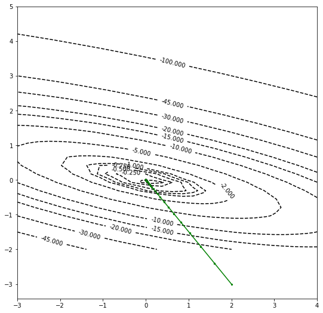

```python
# Print R, C, eigenvalues, conditional number
R1 = 0.001
print("R: ", R1)
print("C: ", C1)
print("eigenvalues: ", eig1)
print("conditional number: ", con_num1, "\n")


#The following visualization uses the initial parameters.
n = 30
ex1 = np.linspace(-3,4, num=n)
ex2 = np.linspace(-2,5, num=n)
grid1, grid2 = np.meshgrid(ex1, ex2)

## fill the grid via looping.  You may prefer to use ufuncs instead.
z = np.empty_like(grid1)
for i in range(z.shape[0]):
    for j in range(z.shape[1]):
        x = np.array([grid1[i,j], grid2[i,j]])
        z[i,j] = f(x,A) #f(x) in 2D

## Make the plot
plt.figure(figsize=(9,9))
p = plt.contour(grid1, grid2, z,
                levels = [-1000,-500,-300,-100,60,-45,-30,-20,-15,-10,-5,-2,-1,-0.75,-0.5,-0.25,-0.1,0],
                colors = 'black')
plt.clabel(p, inline=1, fontsize=10)

i = 0
while i < count1:
    plt.scatter([xlist1[i][0,0], xlist1[i+1][0,0]], [xlist1[i][1,0], xlist1[i+1][1,0]], c='green', s=5)
    plt.plot([xlist1[i][0,0], xlist1[i+1][0,0]], [xlist1[i][1,0], xlist1[i+1][1,0]], c='green')
    i+=1
```

```
R:  0.01
C:  [[2. 1.]
 [1. 2.]]
eigenvalues:  [3. 1.]
conditional number:  1.7320508075688772
```

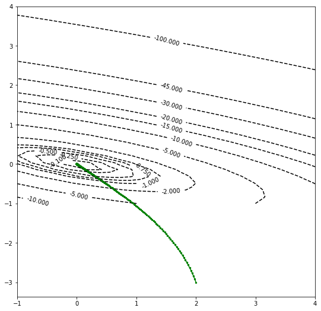

```python
# Print R, C, eigenvalues, conditional number
R2 = 0.01
print("R: ", R2)
print("C: ", C2)
print("eigenvalues: ", eig2)
print("conditional number: ", con_num2, "\n")


#The following visualization uses the initial parameters.
n = 30
ex1 = np.linspace(-1,4, num=n)
ex2 = np.linspace(-1,4, num=n)
grid1, grid2 = np.meshgrid(ex1, ex2)

## fill the grid via looping.  You may prefer to use ufuncs instead.
z = np.empty_like(grid1)
for i in range(z.shape[0]):
    for j in range(z.shape[1]):
        x = np.array([grid1[i,j], grid2[i,j]])
        z[i,j] = f(x,A) #f(x) in 2D

## Make the plot
plt.figure(figsize=(9,9))
p = plt.contour(grid1, grid2, z,
                levels = [-1000,-500,-300,-100,60,-45,-30,-20,-15,-10,-5,-2,-1,-0.75,-0.5,-0.25,-0.1,0],
                colors = 'black')
plt.clabel(p, inline=1, fontsize=10)

i = 0
while i < count2:
    plt.scatter([xlist2[i][0,0], xlist2[i+1][0,0]], [xlist2[i][1,0], xlist2[i+1][1,0]], c='green', s=5)
    plt.plot([xlist2[i][0,0], xlist2[i+1][0,0]], [xlist2[i][1,0], xlist2[i+1][1,0]], c='green')
    i+=1
```

[output not shown]

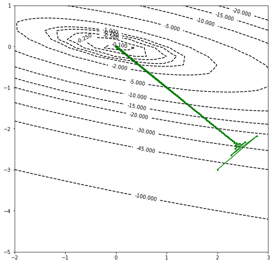

```python
# Print R, C, eigenvalues, conditional number
R3 = 0.01
print("R: ", R3)
print("C: ", C3)
print("eigenvalues: ", eig3)
print("conditional number: ", con_num3, "\n")


#The following visualization uses the initial parameters.
n = 30
ex1 = np.linspace(-2,3, num=n)
ex2 = np.linspace(-5,1, num=n)
grid1, grid2 = np.meshgrid(ex1, ex2)

## fill the grid via looping.  You may prefer to use ufuncs instead.
z = np.empty_like(grid1)
for i in range(z.shape[0]):
    for j in range(z.shape[1]):
        x = np.array([grid1[i,j], grid2[i,j]])
        z[i,j] = f(x,A) #f(x) in 2D

## Make the plot
plt.figure(figsize=(9,9))
p = plt.contour(grid1, grid2, z,
                levels = [-1000,-500,-300,-100,60,-45,-30,-20,-15,-10,-5,-2,-1,-0.75,-0.5,-0.25,-0.1,0],
                colors = 'black')
plt.clabel(p, inline=1, fontsize=10)

i = 0
while i < count3:
    plt.scatter([xlist3[i][0,0], xlist3[i+1][0,0]], [xlist3[i][1,0], xlist3[i+1][1,0]], c='green', s=5)
    plt.plot([xlist3[i][0,0], xlist3[i+1][0,0]], [xlist3[i][1,0], xlist3[i+1][1,0]], c='green')
    i+=1
```

#### 13. Comment on your results. How is the convergence speed related to the matrix condition number?

##### comments

it seems like that as the matrix's condition number gets larger, the convergence speed gets a lot lower.

### 2. Outliers in di erent distributions

The task in this problem is similar to lab 1 conduct a series of MC simulations and see how often do we get outliers of given size. How often do we get statistically signi cant results even if there is nothing signi cant in our model.  
You will generate a large number R (1000 is a good choice) of random samples of given size N (with N between 10 and 10 millions), and take mean of these samples. What is the distribution of the means? How does the distribution depend on the sample size N? And what's di erence if the random numbers are drawn from di erent samples?

### 2.1 Normal Distribution

#### 1. Pick your number of repetitions R (1000 is a good choice), and sample sizes N (10, 1000, 100,000 are good choices, but you may want to adjust if the latter is too slow).

```python
R = 1000
N = 10
```

#### 2. For R times create sample of N of standard normals, and take the mean of it. You'll have R means of N standard normals.

#### 3. Compute the mean-of-means, it's standard deviation, and 95% con dence region.

The 95% con dence region is the opposite of computing the percentage of observations that t into the interval. The easiest way to nd it is using sample quantiles. Check out the quantile function in R, or np.percentile function in python. For instance, np.percentile(x, 10) will give the 10th percentile q10 of an array x. 10th percentile is such a value that 10% of the sample values are smaller than that value.

```python
def normal_distri(R, N):
    mus=[] # create a list of mean
    for i in range(R):
        n = np.random.normal(size = N) # find random normal from N
        mus.append(np.mean(n)) # add the new random normal to the means list
    mu = np.mean(mus) # find the mean of the means list
    std = np.std(mus) # get the std for the means
    ci_lower = mu - 1.96*std # get the lower range of the 95% confidence interval
    ci_upper = mu + 1.96*std # get the upper range of the 95% confidence interval
    ci_low = np.percentile(mus, 2.5)
    ci_up = np.percentile(mus, 97.5)

    print("R: ", R, "\n")
    print("N: ", N, "\n")
    print("mu of the means list: ", mu, "\n")
    print("standard deviation of the means list: ", std, "\n")
    print("95% ci: ", "[", ci_lower, ", ", ci_upper, "]", "\n")
    print("95% ci percentile: ", "[", ci_low, ", ", ci_up, "]", "\n")

normal_distri(R,N)
```

```
R:  1000

N:  10

mu of the means list:  0.00881167141622335

standard deviation of the means list:  0.3074623188512945

95% ci:  [ -0.5938144735323139 ,  0.6114378163647605 ]

95% ci percentile:  [ -0.5785738153762069 ,  0.6023239626742947 ]
```

#### 4. Repeat the above with three di erent (and very di erent) N-s, such as 10, 1000, 100,000. Show how the mean-of-means, it's standard deviation, and the con dence region depends on N.

```python
normal_distri(1000,10)

normal_distri(1000,1000)

normal_distri(1000,100000)
```

```
R:  1000

N:  10

mu of the means list:  0.01393812968472316

standard deviation of the means list:  0.3048598472237236

95% ci:  [ -0.5835871708737751 ,  0.6114634302432215 ]

95% ci percentile:  [ -0.5649987232164931 ,  0.6362783209496342 ]

R:  1000

N:  1000

mu of the means list:  0.00038283396348576395

standard deviation of the means list:  0.031197559548811905

95% ci:  [ -0.06076438275218557 ,  0.061530050679157094 ]

95% ci percentile:  [ -0.060947333262379354 ,  0.06063822997245834 ]

R:  1000

N:  100000

mu of the means list:  -4.537664516119737e-05

standard deviation of the means list:  0.003159775513167844

95% ci:  [ -0.006238536650970171 ,  0.006147783360647776 ]

95% ci percentile:  [ -0.006439069614399285 ,  0.006011767515171395 ]
```

### 2.2 Pareto distribution

Normal distribution has very nice properties, despite it's density function looking a little bit . . . nasty. But there are many things in our world that are not well approximated by normal distribution. Ex- amples include size of cities, links to webpages, popularity of actors, number of citations of researchers, size of wild res. . . . All of these are very inequal there are cities that are enourmous, but most of towns are small. Some researchers have hundreds of thousands of citations but most of them only a few. This kind of outcomes can be described by Pareto distribution. There are many ways to de ne it, but let's do it like this:  
**F(x)=1− x and f(x)=kxk0x−(k+1) wherex >= x0 andk>0.**  
The parameter x0 (called location) tells where the distribution begins and k describes how fast it falls for large x values (called shape). The expected value for Pareto random variable is  
**EX= k/(k-1)* x0 for k>1.**  
Note that for k 1 the expected value does not exist! Your task is to explore what the property means in practice.  
Set x0 = 1 and pick a k 1. Note: depending on the software you use, it may parameterized di erently and you may have to adjust the parameter choice accordingly. If you use np.random.pareto (python) or VGAM::rpareto (R), the parameterization is as described here.

#### 5. Create a large number of pareto random variables. Show their distribution on a histogram. Attempt to make the histogram look good.

Note: you'll see it is hard to make it to look good. But you may try to do it in log-log scale, and set an upper limit to the variables you will display, say only values x < 100 on the histogram.

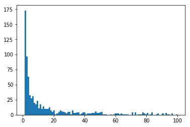

```python
k, x0 = 0.3, 1  # shape and mode

s = (np.random.pareto(k, 1000) + 1) * x0
s
plt.hist(s, bins=100, range=(s.min(),100))
```

```python
#similar to the normal distribution, define pareto distribution
Rp = 1000
Np = 10
x0 = 1
def pareto_distri(Rp, Np):
    mus=[] # create a list of mean
    for i in range(Rp):
        n = np.random.pareto(x0, Np) # find random normal from N
        mus.append(np.mean(n)) # add the new random normal to the means list
    mu = np.mean(mus) # find the mean of the means list
    std = np.std(mus) # get the std for the means
    ci_low = np.percentile(mus, 2.5)
    ci_up = np.percentile(mus, 97.5)

    print("Rp: ", Rp, "\n")
    print("Np: ", Np, "\n")
    print("mu of the means list: ", mu, "\n")
    print("standard deviation of the means list: ", std, "\n")
    print("95% ci percentile: ", "[", ci_low, ", ", ci_up, "]", "\n")

pareto_distri(Rp,Np)
```

```
Rp:  1000

Np:  10

mu of the means list:  16.391902467175417

standard deviation of the means list:  251.15043880912813

95% ci percentile:  [ 0.7719432714356314 ,  45.673071374613336 ]
```

Now repeat exactly the same task as you did above with random normals:

#### 6. Pick R and three N values

#### 7. Create R times a sample of N Pareto values, and take a mean of those.

#### 8. Compute the mean-of-the-means, it's standard deviation, and 95% con dence region.

#### 9. Repeat it with 3 di erent N-s.

```python
pareto_distri(1000,10)
pareto_distri(1000,1000)
pareto_distri(1000,100000)
```

```
Rp:  1000

Np:  10

mu of the means list:  9.491137064737584

standard deviation of the means list:  45.187043959174574

95% ci percentile:  [ 0.7600082234084944 ,  45.18018866696688 ]

Rp:  1000

Np:  1000

mu of the means list:  14.822420914187104

standard deviation of the means list:  64.19312064389749

95% ci percentile:  [ 4.810819763105914 ,  48.492849471599826 ]

Rp:  1000

Np:  100000

mu of the means list:  17.98820983009541

standard deviation of the means list:  36.421715854196925

95% ci percentile:  [ 9.288752885456356 ,  59.140875823889836 ]
```